# Economy and institutions

Session 2

Luis F. Gómez L.

luis.gomezl@unimilitar.edu.co

Distance Learning Faculty

29 January, 2026

# Please Read Me

- Check the message **Welcome greeting** published in Announcements forum.
- Dear student please edit your profile uploading a photo where your face is clearly visible.
- If you want to participate, please fill out the following survey: **Primer corte 30% > Learning Activities > Tu opinión sobre la economía colombiana**
- This presentation is based on (Cardenas, 2020, Chapter 4)
- **Purpose**
  - Analyze the role of institutions in the economy

# Some informal institutions

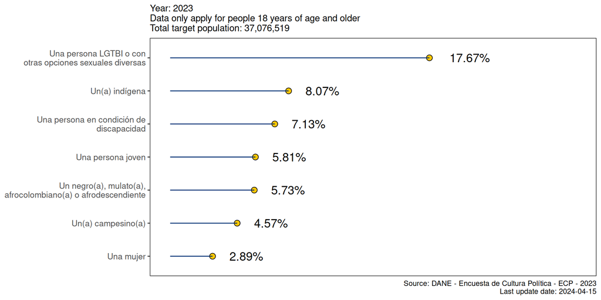

Figure 1: Percentage of people who would never vote for

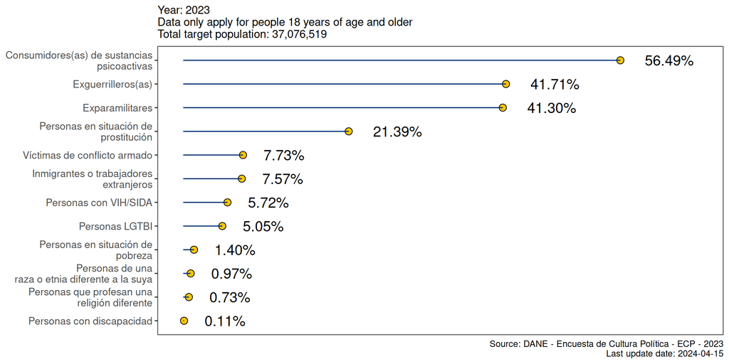

Figure 2: Percentage of people who would never like to have a certain neighbor

# Institutions and economic growth

- The big question: **Why are some countries much poorer than others?**
  - According to (Acemoglu et al., 2005, pp. 389–393) the key variables are the **political institutions** and the **distribution of resources**
- The **political institutions** are the rules that govern incentives in politics. They determine (Acemoglu & Robinson, 2013, pp. 79–80):
  - How the government is chosen
  - Which part of the government has the right to do what
  - Who has power in society
  - To what ends that power can be used
- The **political institutions** determine the **economic institutions**
  - The **economic institutions** are (Acemoglu & Robinson, 2013, pp. 73–74):
    - The rules influencing how the economy works
    - The incentives that motivate people
- The argument by (Acemoglu et al., 2005, pp. 389–393) in relation to how **political institutions** and the **distribution of resources** determine economic performance is as follows:
  - Economic institutions shape the incentives of key economic actors in society where they influence investments in physical and human capital and technology, and the organization of production (Acemoglu et al., 2005, pp. 389–390).

$$\text{economic institutions}_t \Longrightarrow
\begin{cases}
\text{economic performance}_t \\
\text{distribution of resources}_{t+1}
\end{cases}$$

- The argument by (Acemoglu et al., 2005, pp. 389–393) in relation to how **political institutions** and the **distribution of resources** determine economic performance is as follows:
  - Economic institutions are determined as collective choices of the society. However, there is no guarantee that all individuals will prefer the same set of economic institutions because they lead to different distributions of resources. So, there will typically be a conflict of interest among various individuals over the choice of economic institutions (Acemoglu et al., 2005, p. 390).
  - So how are economic institutions determined? Whichever individuals have more political power are likely to secure the set of economic institutions that they prefer.

$$\text{political power}_t \Longrightarrow \text{economic institutions}_t$$

- There are 2 components of political power (Acemoglu et al., 2005, pp. 390–391):
  - **De jure (institutional)**: refers to power that originates from the political institutions in society
  - **De facto**: the power that derives from actual influence, irrespective of the formal institutional framework. It can be based on factors such as wealth, control of resources, or the ability to mobilize people, among others.
- In the case of the **de jure (institutional)** power according to (Acemoglu et al., 2005, p. 391) this aspect implies that:

$$\text{political institutions}_t \Longrightarrow \text{de jure political power}_t$$

- In the case of the **de facto** power according to (Acemoglu et al., 2005, p. 391) this aspect depends on 2 sources:
  - The ability of the group of individuals to act together and avoid the incentives of some individuals to benefit without contributing.
    - In the economic literature this is known as **solving the collective action problem** and the **free-rider problem**
  - The economic resources of the group which determine the ability to use existing political institutions and force against other individuals
- Because (Acemoglu et al., 2005, p. 391) don’t have a satisfactory theory about how individuals solve the **collective action problem** they focus on:

$$\text{distributions of resources}_t \Longrightarrow \text{de facto political power}_t$$

- Also (Acemoglu et al., 2005, pp. 391–392) point out that political institutions and the distribution of resources tend to change relatively slowly but determine economic institutions and economic performance both directly and indirectly.

$$\text{political power}_t \Longrightarrow \text{political institutions}_{t+1}$$

- Putting all these pieces together in Figure 3 it is shown a simplistic schematic representation of this framework.

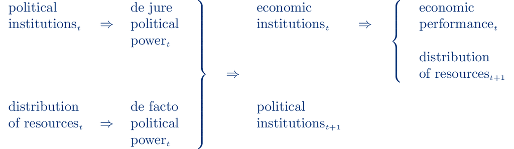

Figure 3: Acemoglu, Johnson and Robinson framework (Acemoglu et al., 2005, p. 392)

# Acknowledgments

- To my family that supports me
- To the taxpayers of Colombia and the [**UMNG students**](https://www.umng.edu.co/estudiante) who pay my salary
- To the [**Business Science**](https://www.business-science.io/) and [**R4DS Online Learning**](https://www.rfordatasci.com/) communities where I learn [**R**](https://www.r-project.org/about.html) and [**$\pi$-thon**](https://www.python.org/about/)
- To the [**R Core Team**](https://www.r-project.org/contributors.html), the creators of [**RStudio IDE**](https://posit.co/download/rstudio-desktop/), [**Positron**](https://positron.posit.co/), [**Quarto**](https://quarto.org/) and the authors and maintainers of the packages [**tidyverse**](https://CRAN.R-project.org/package=tidyverse), [**janitor**](https://CRAN.R-project.org/package=janitor) and [**tinytex**](https://CRAN.R-project.org/package=tinytex) for allowing me to access these tools without paying for a license

# References

Acemoglu, D., Johnson, S., & Robinson, J. A. (2005). Chapter 6 Institutions as a Fundamental Cause of Long-Run Growth. In *Handbook of Economic Growth* (Vol. 1, pp. 385–472). Elsevier. https://doi.org/10.1016/S1574-0684(05)01006-3

Acemoglu, D., & Robinson, J. A. (2013). *Why nations fail: The origins of power, prosperity, and poverty* (Paperback ed). Profile Books.

Cardenas, M. (2020). *Introducción a la Economía Colombiana* (4th ed.). Alfaomega.